# Data Visualization with ggplot2 (Part 3)

## Diagnostic Plots

- `ggfortify`: An all-purpose plot converter between `base` graphics and `ggplot2` `grid` graphics.

#### **`lm`**

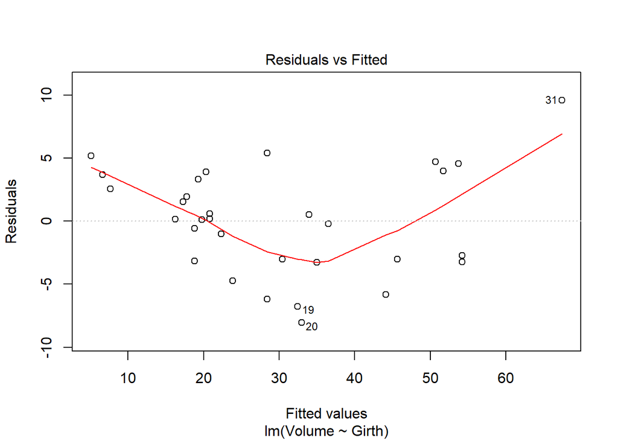

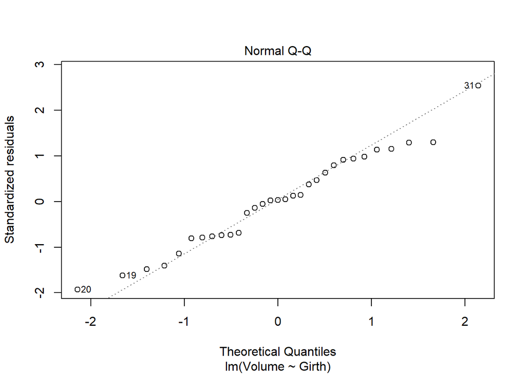

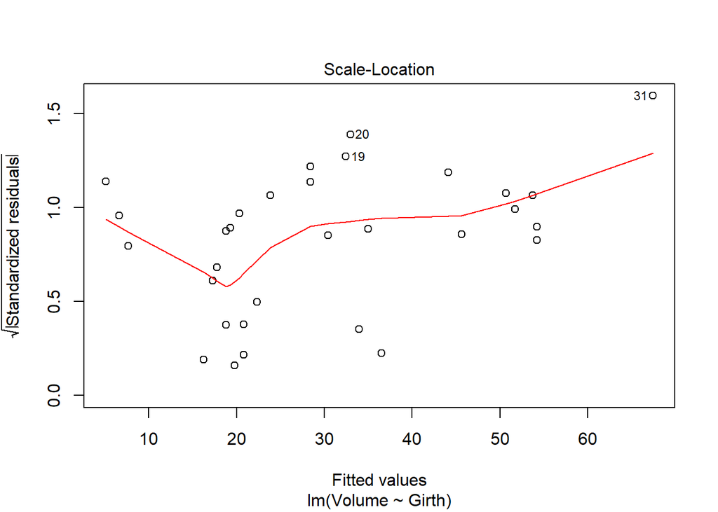

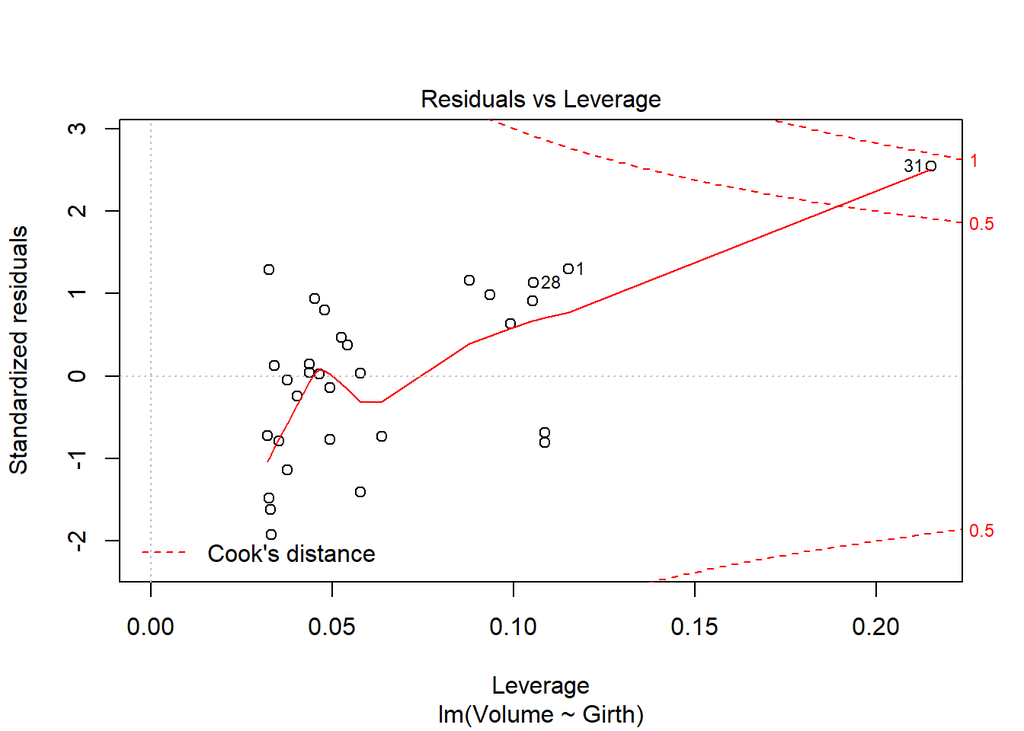

```r
# Create linear model: res
res <- lm(Volume ~ Girth, data = trees)

# Plot res (base)
plot(res)
```

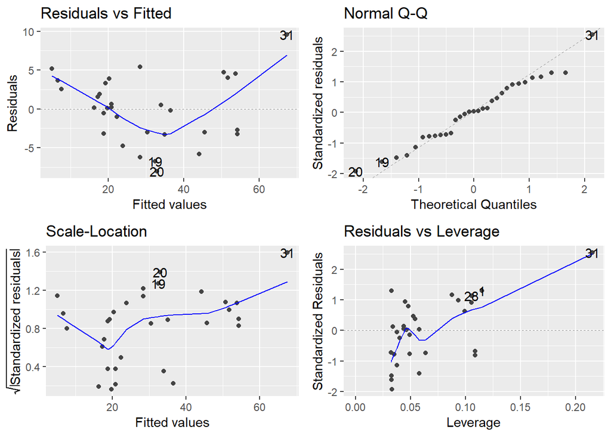

```r
# Import ggfortify and use autoplot()
# ncol = 2 to convert this to a ggplot2 plot.
library(ggfortify)
autoplot(res, ncol =2)
```

#### **`mts` or `ts`**

Time series objects (class `mts` or `ts`) also have their own methods for `plot()`.  
`ggfortify` can also take advantage of this functionality.

```r
library(vars)
Canda <- data('Canada')
class(Canada)
```

```
## [1] "mts" "ts"
```

```r
# Inspect structure of Canada
str(Canada)
```

```
##  Time-Series [1:84, 1:4] from 1980 to 2001: 930 930 930 931 933 ...
##  - attr(*, "dimnames")=List of 2
##   ..$ : NULL
##   ..$ : chr [1:4] "e" "prod" "rw" "U"
```

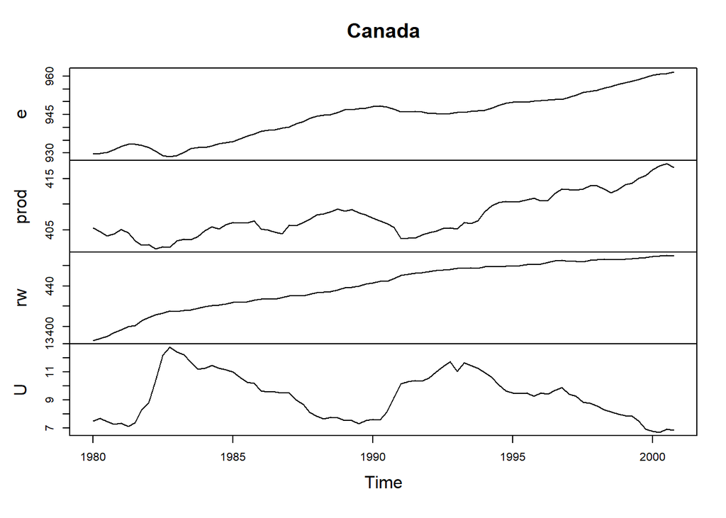

```r
# Call plot() on Canada
plot(Canada)
```

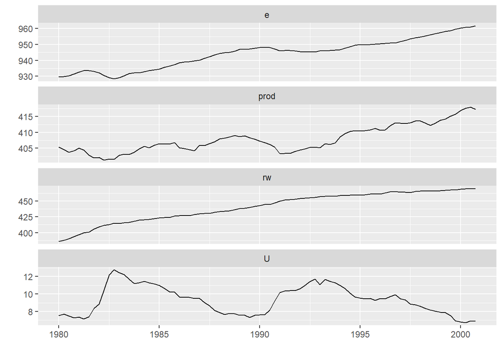

```r
# Call autoplot() on Canada
autoplot(Canada)
```

#### **`dist`**

- `cmdscale()`: From the stats package performs Classical Multi-Dimensional Scaling and returns point coodinates as a matrix.

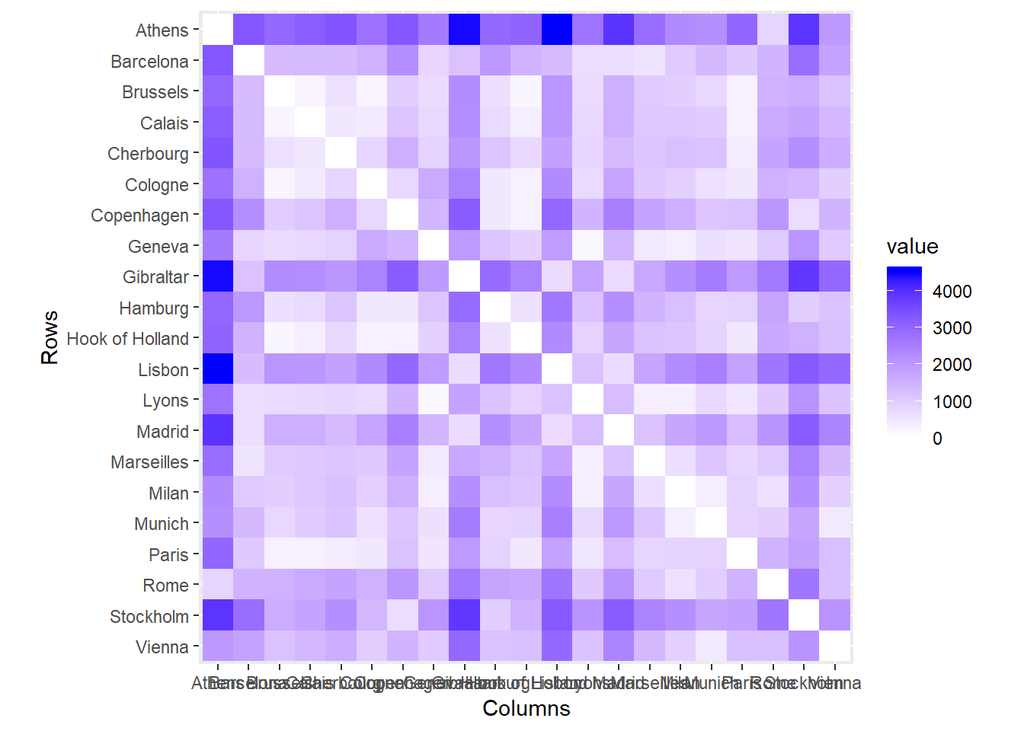

```r
# Autoplot + ggplot2 tweaking
autoplot(eurodist) +
  coord_fixed()
```

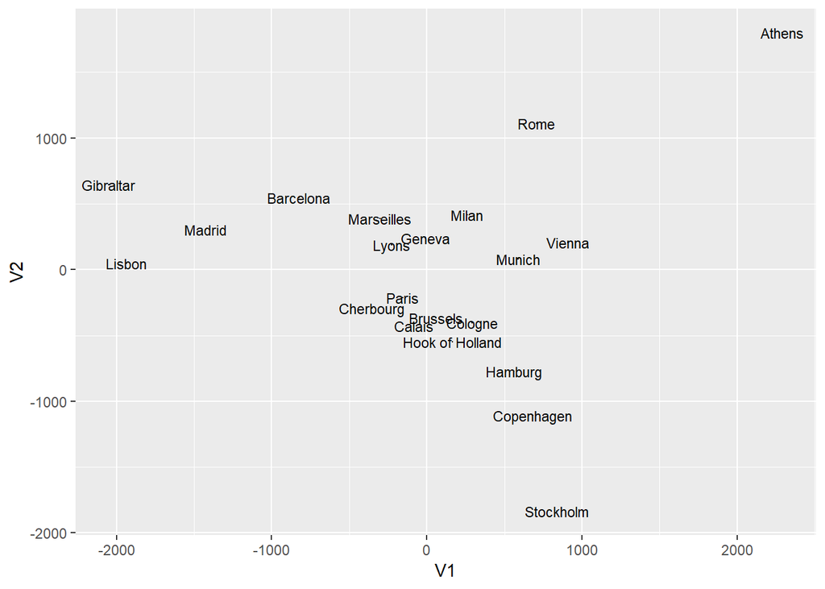

```r
# Autoplot of MDS
autoplot(cmdscale(eurodist, eig = TRUE),
         label = TRUE,
         label.size = 3,
         size = 0)
```

#### **Kmeans & Cluster**

- `kmeans()`, a function in the `stats` package, to perform clustering on `iris[-5]` with 3 groups.

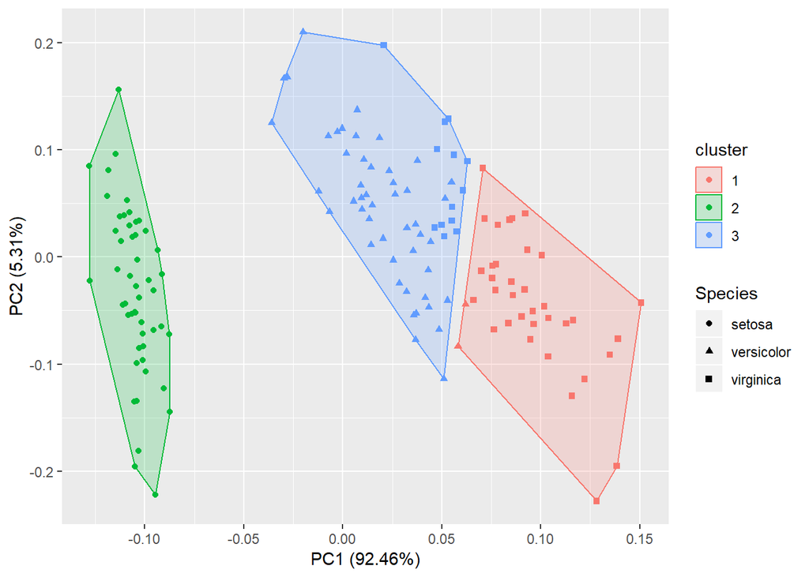

```r
# Perform clustering
iris_k <- kmeans(iris[-5], 3)

# Autoplot: color according to cluster, plus shape according to species
autoplot(iris_k, data = iris, frame = T, shape = 'Species')
```

## Choropleths

- `geom_polygon()`: Make a choropleths like drawing a polygon.

#### **Using `ggplot2::map_data()`**

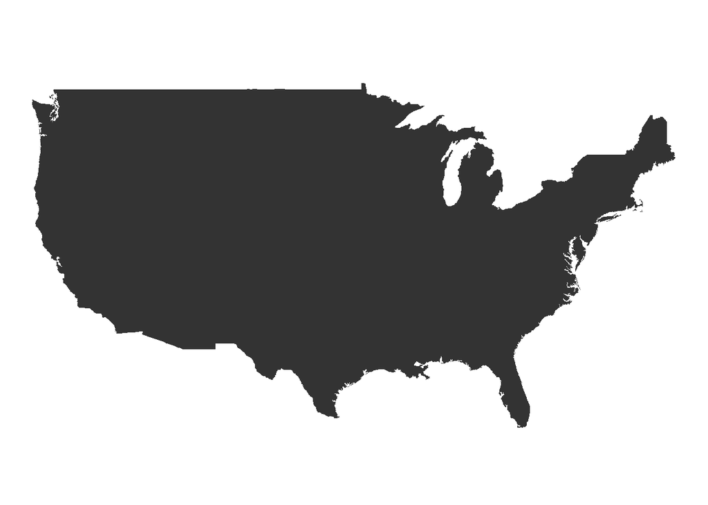

```r
# Get the map data
library(ggplot2)
usa<- map_data('usa')

library(ggmap)
# Build the map
ggplot(usa, aes(x = long, y = lat, group = group)) +
  geom_polygon() +
  coord_map() +
  theme_nothing()
```

#### **Read from Shapefiles**

- Use `readOGR()` to read in the shapefiles and store the data as germany.
  - `dsn`, data source name, the folder of the shapefiles. Should be “shapes”.
  - `layer`, the level you are interested in. You want state information, so “DEU_adm1”.

```r
# All required packages are available
# Import shape information: germany
library(rgdal)
germany <- readOGR(dsn = 'D:/Downloads/shape_files', layer = 'DEU_adm1')
```

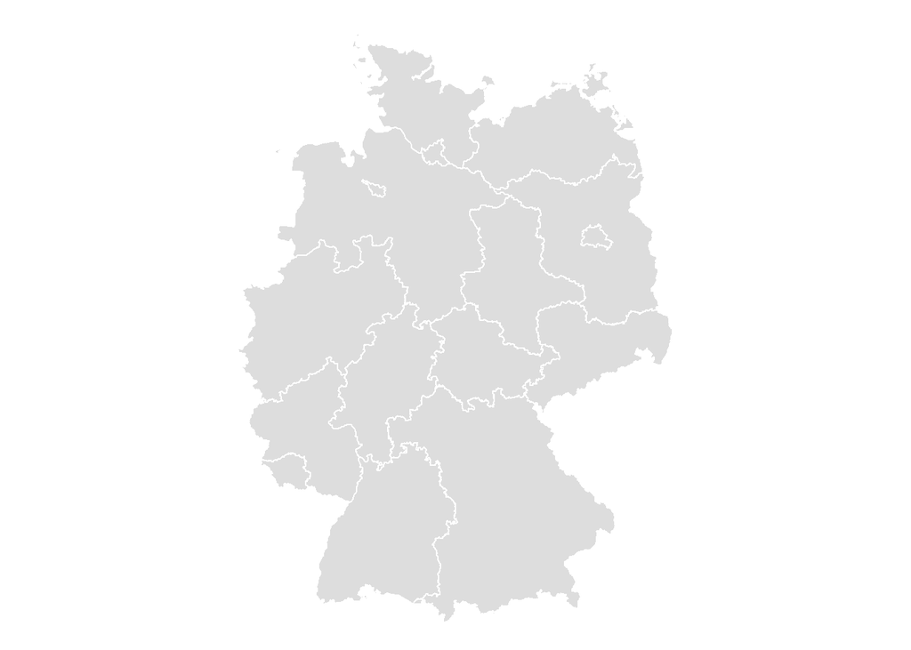

```r
# fortify germany: bundes
library(ggfortify)
bundes <- fortify(germany)

# Plot map of germany
library(ggmap)
ggplot(bundes, aes(x = long, y = lat, group = group)) +
    geom_polygon(fill = '#DDDDDD', col = 'white') +
    coord_map() +
    theme_nothing()
```

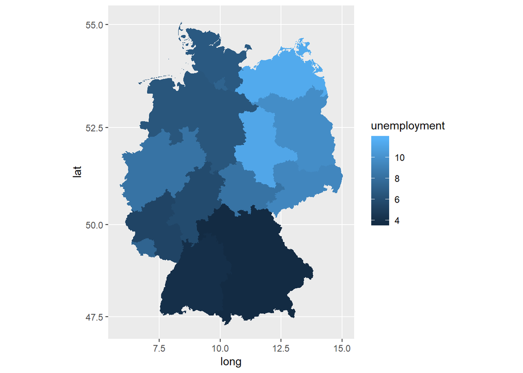

```r
# Import unemployment of germany
unemp <- read.table('D:/Downloads/germany_unemployment.txt', header = T)

# re-add state names to bundes
bundes$state <- factor(as.numeric(bundes$id))
levels(bundes$state) <- germany$NAME_1

# Merge bundes and unemp: bundes_unemp
bundes_unemp <- merge(bundes, unemp)

# Update the ggplot call
library(ggthemes)
ggplot(bundes_unemp, aes(x = long, y = lat, group = group, fill = unemployment)) +
  geom_polygon() +
  coord_map()
```

```r
  #theme_map()
  #Cause legend & map overlapping
```